# 04 — Perturbation effect vectors and response similarity

# Input and scope

Each column of the Part 2 effect matrix is one perturbation-level log2 CPM difference from the non-targeting aggregate. The columns summarize selected, sufficiently represented perturbations from one public experiment. Cell-level DE, raw-count aggregate profiles, and effect vectors have distinct statistical units.

```r
library(dplyr)
library(ggplot2)
library(pheatmap)
library(ggrepel)
library(tibble)
```

```r
delta <- readRDS("data/processed/03_perturbation_effect_matrix.rds")
pseudobulk <- readRDS("data/processed/03_pseudobulk_raw_counts.rds")
stopifnot(is.matrix(delta), all(colnames(delta) %in% colnames(pseudobulk)))
X <- t(delta)
cat("Perturbations x genes:", paste(dim(X), collapse=" x "), "\n")
```

```
## Perturbations x genes: 12 x 2000
```

### Interpretation

Each of the 12 rows represents a perturbation-level effect vector across the same 2,000 genes. These vectors summarize aggregate differences from control and are distinct from individual-cell measurements or replicate-aware estimates.

# Cosine similarity

Cosine similarity measures agreement in response direction and is less sensitive than Euclidean distance to overall response magnitude. Zero-magnitude vectors are rejected because their cosine is undefined.

```r
norms <- sqrt(rowSums(X^2))
stopifnot(all(norms > 0))
unit <- sweep(X, 1, norms, "/")
cos_sim <- tcrossprod(unit)
diag(cos_sim) <- 1
pairs <- as.data.frame(as.table(cos_sim)) |>
  setNames(c("target_a", "target_b", "cosine")) |>
  filter(as.character(target_a) < as.character(target_b)) |>
  arrange(desc(cosine))
print(head(pairs, 10))
```

```
##    target_a target_b    cosine
## 1    DONSON     RRM2 0.6955080
## 2     CPSF3   DONSON 0.5011428
## 3     CPSF3     RRM2 0.4288024
## 4     KIF11   NUP205 0.3677236
## 5      RRM2    SNX15 0.3608240
## 6    DONSON    SNX15 0.3534801
## 7      BUB1    SNX15 0.3391345
## 8    NUP205     RPL3 0.3390103
## 9     CHMP6   DONSON 0.3351044
## 10   NUP205    SNX15 0.3328160
```

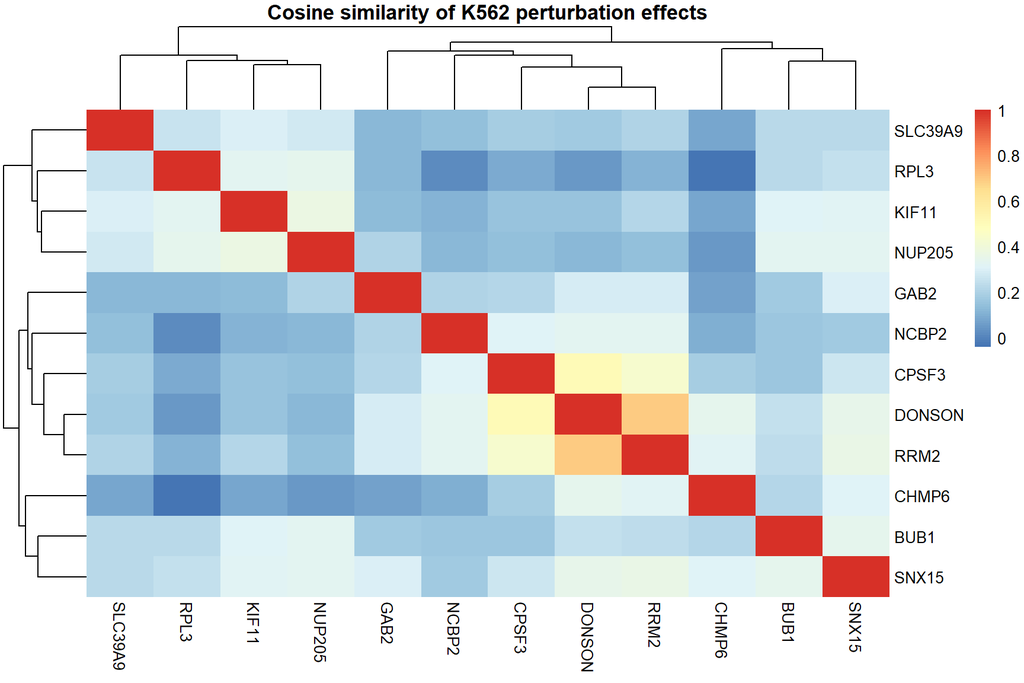

```r
pheatmap(cos_sim, border_color=NA, main="Cosine similarity of K562 perturbation effects")
```

```r
write.csv(pairs, "results/04_response_similarity_pairs.csv", row.names=FALSE)
```

### Key finding

DONSON–RRM2 has the highest cosine similarity (0.696) among the analyzed target pairs, indicating the most similar response direction across the selected genes. Cosine similarity emphasizes direction rather than absolute magnitude. It does not establish a shared pathway, direct interaction, or mechanism.

# Perturbation-level PCA

```r
pca <- prcomp(X, center=TRUE, scale.=FALSE)
pca_df <- data.frame(perturbation=rownames(pca$x), PC1=pca$x[,1], PC2=pca$x[,2])
variance <- 100 * pca$sdev^2 / sum(pca$sdev^2)
cat("PC1 variance (%):", round(variance[1], 2), "PC2 variance (%):", round(variance[2], 2), "\n")
```

```
## PC1 variance (%): 23.22 PC2 variance (%): 19.73
```

```r
print(pca_df)
```

```
##         perturbation         PC1        PC2
## BUB1            BUB1  -2.1317299   4.166412
## KIF11          KIF11  -2.0407450   5.351191
## DONSON        DONSON  -0.3510278  -8.817272
## NUP205        NUP205  -1.1520478   5.771883
## RPL3            RPL3  -1.5977214   7.324125
## GAB2            GAB2  19.2172733   2.117942
## RRM2            RRM2  -0.9359695  -2.990717
## CHMP6          CHMP6 -10.5735830  -4.146598
## NCBP2          NCBP2   3.4532483 -11.231946
## SLC39A9      SLC39A9  -2.1240368   4.990441
## SNX15          SNX15  -1.4516172   3.238853
## CPSF3          CPSF3  -0.3120432  -5.774314
```

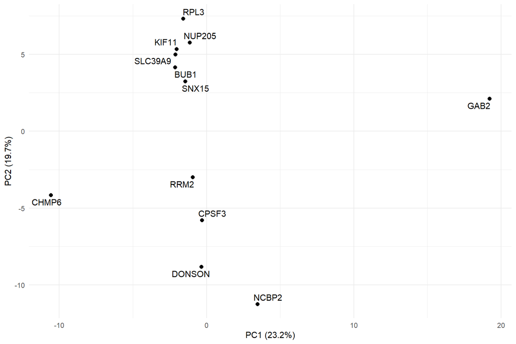

```r
ggplot(pca_df, aes(PC1, PC2, label=perturbation)) + geom_point(size=2) +
  ggrepel::geom_text_repel(max.overlaps=Inf) +
  labs(x=paste0("PC1 (", round(variance[1],1), "%)"), y=paste0("PC2 (", round(variance[2],1), "%)")) + theme_minimal()
```

```r
write.csv(pca_df, "results/04_perturbation_PCA.csv", row.names=FALSE)
```

### Interpretation

Perturbation-level PC1 and PC2 account for 23.22% and 19.73% of variation among these effect vectors. Their plot summarizes differences across the focused 12-target cohort; point distances can reflect both response direction and magnitude and need not imply mechanistic relatedness.

# Response clustering

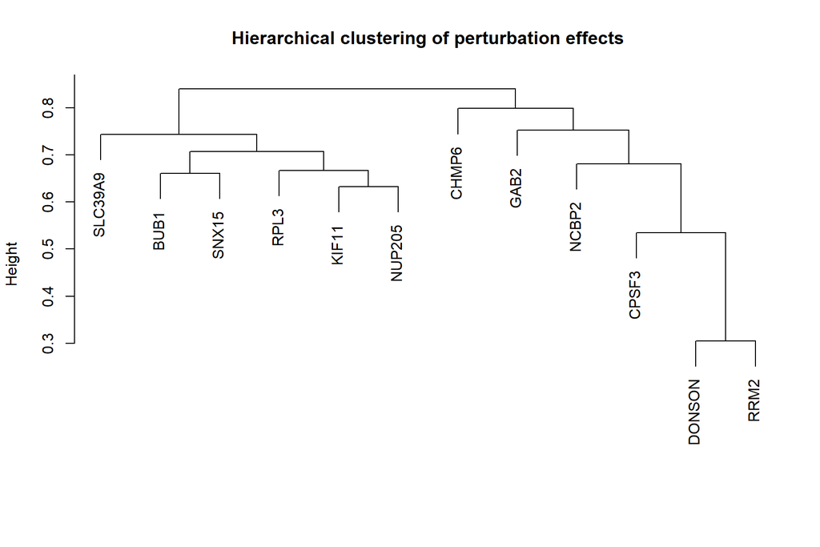

```r
distance <- 1-cos_sim
distance[distance < 0] <- 0
hc <- hclust(as.dist(distance), method="average")
plot(hc, main="Hierarchical clustering of perturbation effects", xlab="", sub="")
```

```r
cluster_id <- cutree(hc, k=3)
cluster_table <- data.frame(perturbation=names(cluster_id), response_cluster=unname(cluster_id))
print(cluster_table |> arrange(response_cluster, perturbation))
```

```
##    perturbation response_cluster
## 1          BUB1                1
## 2         KIF11                1
## 3        NUP205                1
## 4          RPL3                1
## 5       SLC39A9                1
## 6         SNX15                1
## 7         CPSF3                2
## 8        DONSON                2
## 9          GAB2                2
## 10        NCBP2                2
## 11         RRM2                2
## 12        CHMP6                3
```

```r
write.csv(cluster_table, "results/04_response_clusters.csv", row.names=FALSE)
```

### Interpretation

Average-linkage clustering groups similar response directions into clusters of six, five, and one perturbation. This grouping can guide follow-up comparisons, but the three-cluster cut was chosen for inspection. The singleton CHMP6 represents an outlying response pattern in this cohort, not a new biological subtype.

# Genes associated with response clusters

```r
programs <- bind_rows(lapply(sort(unique(cluster_id)), function(k) {
  members <- names(cluster_id)[cluster_id == k]
  others <- setdiff(colnames(delta), members)
  mean_member <- rowMeans(delta[, members, drop=FALSE])
  mean_other <- rowMeans(delta[, others, drop=FALSE])
  difference <- mean_member - mean_other
  data.frame(response_cluster=k, gene=names(difference), mean_effect=mean_member,
             contrast_to_other_clusters=difference, n_perturbations=length(members)) |>
    slice_max(abs(contrast_to_other_clusters), n=15, with_ties=FALSE)
}))
print(programs)
```

```
##               response_cluster       gene mean_effect
## CPXM1...1                    1      CPXM1 -0.10987867
## CRYM...2                     1       CRYM  0.27530502
## ALAS2...3                    1      ALAS2  0.19837656
## BTG2                         1       BTG2  0.04580694
## LBH...5                      1        LBH -0.40015647
## TUBA1A...6                   1     TUBA1A -0.20300903
## HBZ...7                      1        HBZ  0.15138152
## SLC7A8...8                   1     SLC7A8 -0.05834111
## TMEM158                      1    TMEM158 -0.57812724
## TNFSF10...10                 1    TNFSF10 -0.03605391
## HIST1H3H...11                1   HIST1H3H -0.03918129
## YPEL3                        1      YPEL3 -0.16000984
## CDKN1C                       1     CDKN1C  0.05375127
## IGFL2-AS1                    1  IGFL2-AS1  0.07498921
## LTB...15                     1        LTB  0.38286919
## CRYM...16                    2       CRYM  1.98862098
## CPXM1...17                   2      CPXM1  1.67896338
## ALAS2...18                   2      ALAS2  1.75952272
## HBZ...19                     2        HBZ  1.57564202
## LBH...20                     2        LBH  0.98198699
## AC016629.2                   2 AC016629.2  1.83015918
## SLC7A8...22                  2     SLC7A8  1.19450507
## HIST1H3H...23                2   HIST1H3H  1.14093082
## H19                          2        H19  0.86674980
## HIST1H2BH                    2  HIST1H2BH  0.82906849
## HEMGN                        2      HEMGN  1.11939191
## SLC25A37                     2   SLC25A37  0.96818326
## AC015813.1                   2 AC015813.1  1.22289399
## LTB...29                     2        LTB  0.25431353
## TAC3                         2       TAC3  0.73472000
## LTB...31                     3        LTB  6.51875539
## TNFSF10...32                 3    TNFSF10  3.34321591
## ICAM1                        3      ICAM1  2.50636511
## TUBA1A...34                  3     TUBA1A  2.74057980
## NFKBIA                       3     NFKBIA  2.54001335
## NINJ1                        3      NINJ1  3.02531722
## KLF6                         3       KLF6  2.29467237
## TNFAIP2                      3    TNFAIP2  2.67316906
## SQSTM1                       3     SQSTM1  2.29818806
```

[output cut: 37 more lines]

```
## LTB...31                       6.1943206               1
## TNFSF10...32                   3.1543572               1
## ICAM1                          2.6311930               1
## TUBA1A...34                    2.5710560               1
## NFKBIA                         2.4145325               1
## NINJ1                          2.2675475               1
## KLF6                           2.2588547               1
## TNFAIP2                        2.2505698               1
## SQSTM1                         2.2447786               1
## SAT1                           2.0820422               1
## TUBB2B                         2.0653186               1
## FCGR2A                         2.0314420               1
## IER3                           2.0203030               1
## TUBB2A                         1.9988878               1
## PHLDA2                         1.9155527               1
```

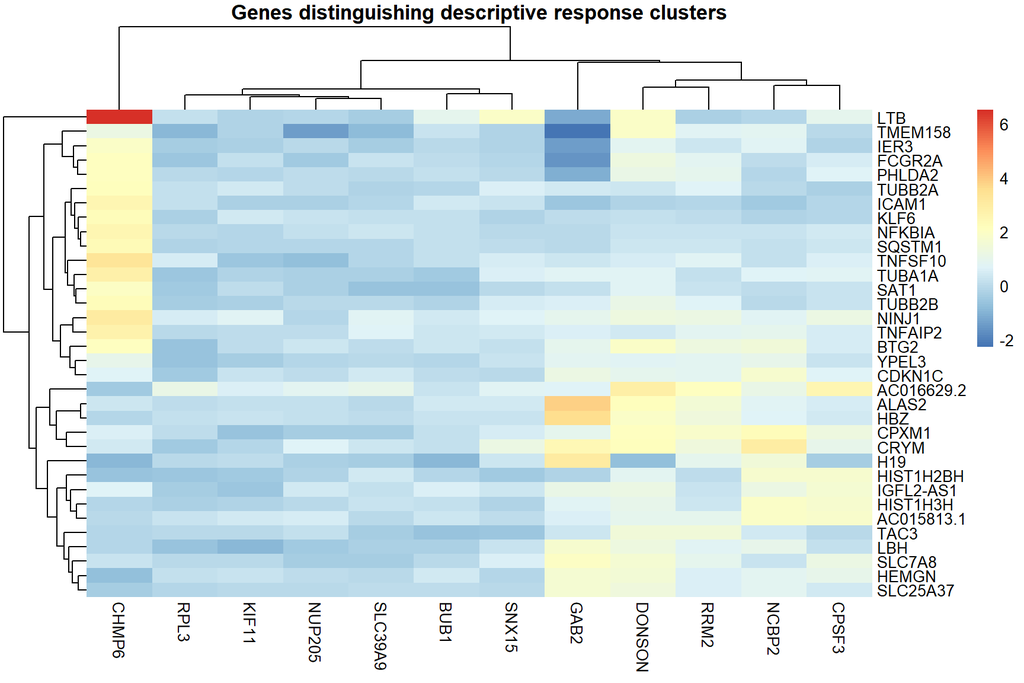

```r
write.csv(programs, "results/04_response_cluster_programs.csv", row.names=FALSE)
pheatmap(delta[unique(programs$gene), , drop=FALSE], scale="none", border_color=NA,
         main="Genes distinguishing descriptive response clusters")
```

### Interpretation

Ranked genes distinguish each cluster's mean effect from the other selected perturbations and suggest descriptive response programs. Cluster 3 contains only CHMP6, so its ranked genes describe one target rather than a shared program. All contrasts use a shared control and lack biological replicates.

# Save

```r
saveRDS(list(X=X, cosine=cos_sim, pca=pca, clusters=cluster_table, programs=programs),
        "data/processed/04_perturbation_embeddings.rds")
```

## Key results

```r
cat("Perturbations:", nrow(X), "effect genes:", ncol(X), "response clusters:", length(unique(cluster_id)), "\n")
```

```
## Perturbations: 12 effect genes: 2000 response clusters: 3
```

```r
cat("Highest cosine pair:", as.character(pairs$target_a[1]), "/", as.character(pairs$target_b[1]), round(pairs$cosine[1], 3), "\n")
```

```
## Highest cosine pair: DONSON / RRM2 0.696
```

```r
cat("PCA variance (%):", round(variance[1], 2), "and", round(variance[2], 2), "\n")
```

```
## PCA variance (%): 23.22 and 19.73
```

- Effect representation: 12 perturbation vectors across 2,000 genes support target-level comparisons.
- Response similarity: DONSON–RRM2 has the highest cosine similarity (0.696), indicating aligned response direction.
- PCA: PC1 and PC2 explain 23.22% and 19.73% of vector variation in this cohort.
- Clustering: response groups contain six, five, and one target; the CHMP6 singleton is an outlier, not a shared program.